# Global Fertility and Life Expectancy Analysis 2017

Data Report 2025-06-19

- 1 Executive Summary
  - 1.1 Introduction
    - 1.1.1 Research Objectives
  - 1.2 Data Loading and Preparation
    - 1.2.1 Dataset Snapshots
  - 1.3 World Map Visualizations
    - 1.3.1 Children per Woman (Fertility Rate) - 2017
    - 1.3.2 Female Life Expectancy - 2017
  - 1.4 Relationship Analysis
    - 1.4.1 Data Merging and Correlation
    - 1.4.2 Scatterplot: Fertility Rate vs Female Life Expectancy
    - 1.4.3 Summary Statistics
  - 1.5 Interpretation
    - 1.5.1 Key Findings:
    - 1.5.2 Personal reflection:

# 1 Executive Summary

This comprehensive analysis examines the relationship between fertility rates and female life expectancy across 197 countries in 2017, revealing a strong negative correlation (r = -0.842) between these key demographic indicators.

## 1.1 Introduction

This report analyzes the relationship between fertility rates (children per woman) and female life expectancy across countries in 2017. We examine global patterns through world maps and explore the correlation between these two important demographic indicators.

### 1.1.1 Research Objectives

- Analyze global patterns in fertility rates and female life expectancy
- Create comprehensive world map visualizations
- Quantify the relationship between these demographic indicators
- Provide insights into global demographic transitions

## 1.2 Data Loading and Preparation

```
## **Dataset Overview:**

## - Fertility dataset: 197 countries × 302 variables

## - Life expectancy dataset: 236 countries × 152 variables
```

### 1.2.1 Dataset Snapshots

**Fertility Rate Dataset Sample** (Children per Woman)

| Position | Country | 1990 | 2000 | 2010 | 2015 | 2017 |
| --- | --- | --- | --- | --- | --- | --- |
| First | Afghanistan | 7.58 | 7.57 | 6.20 | 5.65 | 5.43 |
|  | Angola | 7.27 | 6.64 | 6.19 | 5.77 | 5.60 |
|  | Albania | 3.01 | 2.22 | 1.65 | 1.63 | 1.49 |
| Last | South Africa | 3.72 | 2.41 | 2.45 | 2.36 | 2.28 |
|  | Zambia | 6.57 | 5.92 | 5.36 | 4.78 | 4.57 |
|  | Zimbabwe | 4.88 | 4.01 | 4.04 | 3.91 | 3.77 |

**Sample of Fertility Rate Data (Children per Woman)**

**Female Life Expectancy Dataset Sample** (Years)

| Position | Country | 1990 | 2000 | 2010 | 2015 | 2017 |
| --- | --- | --- | --- | --- | --- | --- |
| First | Aruba | 75.7 | 75.7 | 77.6 | 78.1 | 78.3 |
|  | Afghanistan | 47.7 | 56.6 | 62.3 | 64.2 | 65.6 |
|  | Angola | 45.4 | 49.1 | 59.2 | 63.4 | 64.5 |
| Last | South Africa | 66.9 | 61.1 | 61.2 | 67.0 | 68.6 |
|  | Zambia | 49.4 | 47.3 | 58.2 | 62.8 | 63.9 |
|  | Zimbabwe | 61.6 | 47.3 | 52.7 | 60.5 | 62.0 |

**Sample of Female Life Expectancy Data (Years)**

```
## Countries with fertility data in 2017: 197

## Countries with life expectancy data in 2017: 236
```

## 1.3 World Map Visualizations

### 1.3.1 Children per Woman (Fertility Rate) - 2017

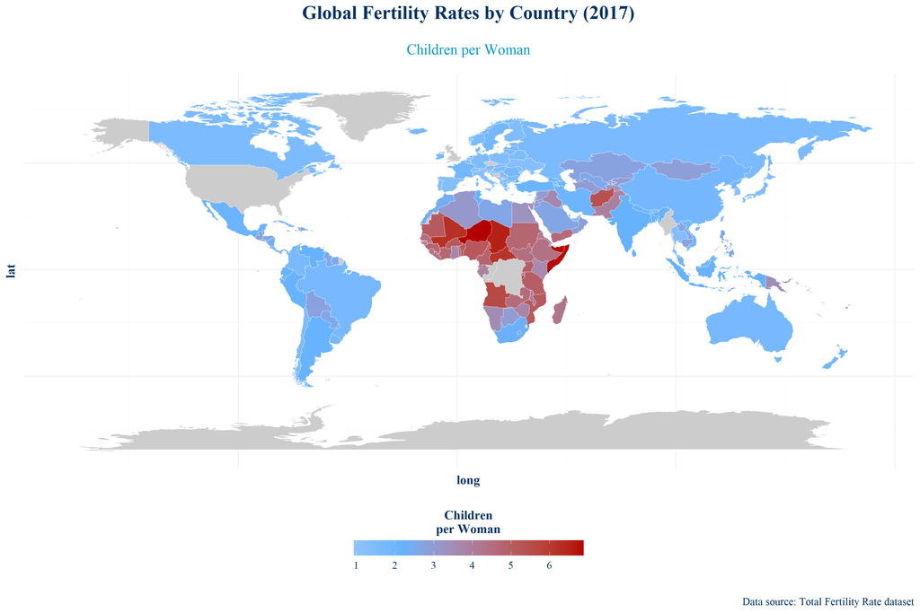

### 1.3.2 Female Life Expectancy - 2017

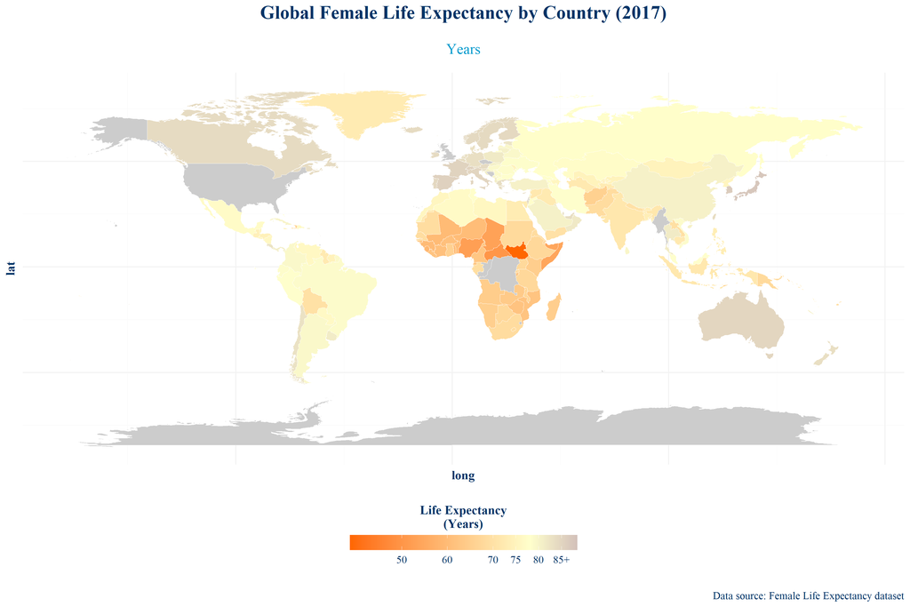

## 1.4 Relationship Analysis

### 1.4.1 Data Merging and Correlation

```
## Number of countries with both indicators: 197

## Pearson correlation coefficient: -0.842
```

### 1.4.2 Scatterplot: Fertility Rate vs Female Life Expectancy

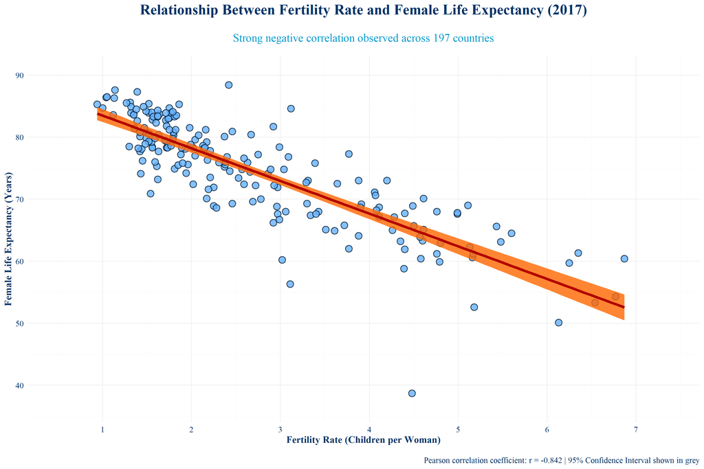

### 1.4.3 Summary Statistics

| Countries | Fertility Mean | Fertility SD | Life Exp. Mean | Life Exp. SD | Correlation |
| --- | --- | --- | --- | --- | --- |
| 197 | 2.7 | 1.35 | 74.53 | 8.46 | -0.842 |

**Summary Statistics for Global Data (2017)**

## 1.5 Interpretation

The analysis reveals a **strong negative correlation** (r = -0.842) between fertility rates and female life expectancy in 2017. This relationship suggests that:

1. **Countries with higher fertility rates tend to have lower female life expectancy**
2. **Countries with lower fertility rates tend to have higher female life expectancy**

This pattern is consistent with demographic transition theory, where countries progress through stages of development characterized by:

- **High fertility, low life expectancy**: Often associated with developing countries with limited healthcare access, education, and economic development
- **Low fertility, high life expectancy**: Typically found in developed countries with better healthcare systems, higher education levels, and greater economic prosperity

The world maps clearly illustrate this pattern, with sub-Saharan African countries generally showing higher fertility rates and lower life expectancy, while European and East Asian countries display the opposite pattern.

### 1.5.1 Key Findings:

- **Average fertility rate**: 2.7 children per woman
- **Average female life expectancy**: 74.53 years
- **Correlation strength**: The correlation of -0.842 indicates a strong negative relationship

This relationship likely reflects underlying socioeconomic factors including healthcare quality, education access (particularly for women), economic development, and cultural factors that influence both reproductive choices and health outcomes.

### 1.5.2 Personal reflection:

I found it fitting to prompt Gemini to comment on this report generated using Cursor…

Even though Pearson’s “r” was used, interpreting the correlation between fertility rate (a ratio, e.g., 2.5 babies/woman) and life expectancy (a linear measure, e.g., 75 years) in a single year has caveats:

**Proxy for Complex Factors:** Both variables are highly influenced by broad socioeconomic development. The correlation largely reflects these shared underlying conditions, not a direct isolated impact of “babies per woman” on longevity.

**Lagged & Cumulative Effects:** The physical toll of fertility on a woman’s health and life expectancy accumulates over time, not instantly within a single year. A single-year “r” misses these delayed and long-term impacts.

**Contextual Impact on Women’s Health:** The effect of fertility on women’s well-being is heavily modified by societal support and gender equality. High fertility in contexts of poor healthcare or gender inequality has a far more detrimental impact on women’s health than in supportive environments. The “r” value doesn’t capture this crucial nuance.

**Ratio vs. Linear - Sensitivity to Scale:** While Pearson’s “r” can be used, the ratio nature of fertility rate means its ‘steps’ (e.g., 1 to 2 vs. 5 to 6 babies) might not have a perfectly linear relationship to the ‘steps’ in life expectancy. If the relationship isn’t truly linear across the entire range, Pearson’s “r” might underestimate or misrepresent the true strength of association, especially at extreme ends of the fertility scale. This is why a scatter plot is crucial to visually assess linearity before relying solely on Pearson’s “r”.

Last personal note: it would be interesting to analyse how total fertility rate impacts **male** life expectancy versus female life expectancy.